# Temperature response of growth-GREAT Experiment

Dushan Kumarathunge

16 April 2018

## Introduction

Many GVMs models use static temperature responses of photosynthesis and respiration (Lombardozzi et al., 2015) and the growth is modelled as the balance between these two processes. However, recent research suggested that these assumptions used in current PBMs are questionable (Cunningham and Read, 2002, Cunningham and Read, 2003) as plants have the capacity for thermal acclimation. Further, the drivers of temperature-growth response are not well understood. In this research, our aim is to improve the current understanding of the temperature response of growth by identifying the important drivers that account for the overall response

## Objectives

Investigate how well a model incorporating temperature responses of photosynthesis and respiration can predict the temperature response of growth

1. What are the key processes contributing to the temperature effect on growth?
2. Using a carbon balance model, can we simulate growth as a function of photosynthesis and respiration?

## Data

[output not shown]

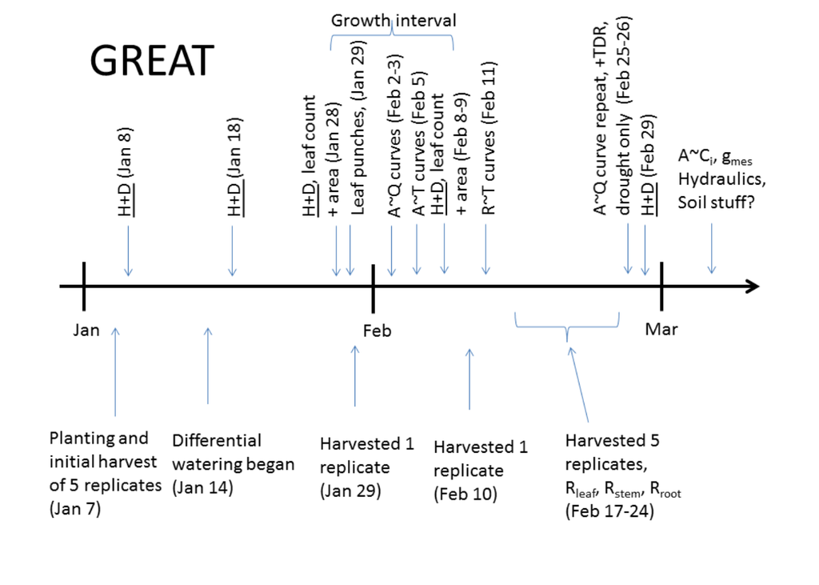

**Figure 1**. Data census of the GREAT experiment

##### Briefly describe the Carbon Balance Model (CBM)

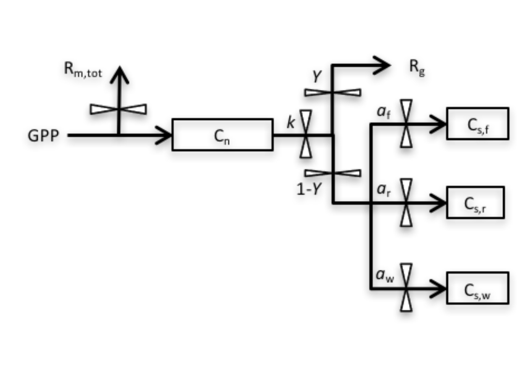

**Figure 2**: Structure of the Carbon Balance Model (CBM). Pools, shown as solid boxes: C<sub>n</sub>, non-structural storage C; C<sub>s,f</sub>, structural C in foliage; C<sub>s,r</sub>, structural C in roots; C<sub>s,w</sub>, structural C in wood. Fluxes, denoted by arrows, include: GPP, gross primary production; R<sub>m,tot</sub>, maintenance respiration; Rg, growth respiration. Fluxes are governed by five key parameters: *k*, storage utilization coefficient; *Y*, growth respiration fraction; *a<sub>f</sub>*, allocation to foliage; *a<sub>w</sub>*, allocation to wood; $a_r = (1-a_f-a_w)$, allocation to roots.

The dynamics of the four carbon pools (C<sub>n</sub>, C<sub>s,f</sub>, C<sub>s,w</sub>, and C<sub>s,r</sub>) are described by four difference equations:

Eqn 1
$$\Delta C_n = GPP - R_{m,tot} - kC_n$$
Eqn 2
$$\Delta C_{s,f} = kC_n(1-Y)a_f$$
Eqn 3
$$\Delta C_{s,w} = kC_n(1-Y)a_w$$
Eqn 4
$$\Delta C_{s,r} = kC_n(1-Y)(1-a_f-a_w)$$

## Parameter estimation for the coupled photosynthesis stomatal conductance model

### 1. Estimation of Vcmax (at 25<sup>o</sup>C), Jmax (at 25<sup>o</sup>C), $\alpha$ (quantum yield of electron transport) and $\theta$ (curvature of the light response curve)

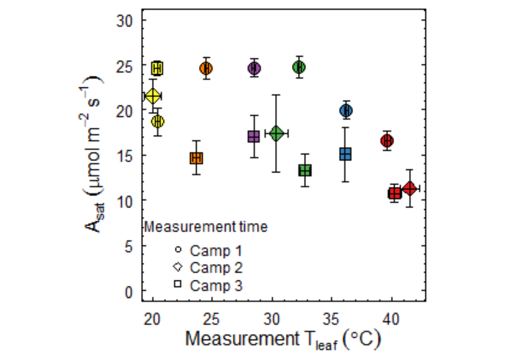

Fig.3 Photosynthesis vs Temperature relationship of seedlings with different age. Circles: 26 DAP (3-Feb-2016), diamonds: 40 DAP and squares: ~50 DAP (26-Feb-2016). Colours depict different growth temperatures. Data used: in-situ Asat measurements of well-watered seedlings.

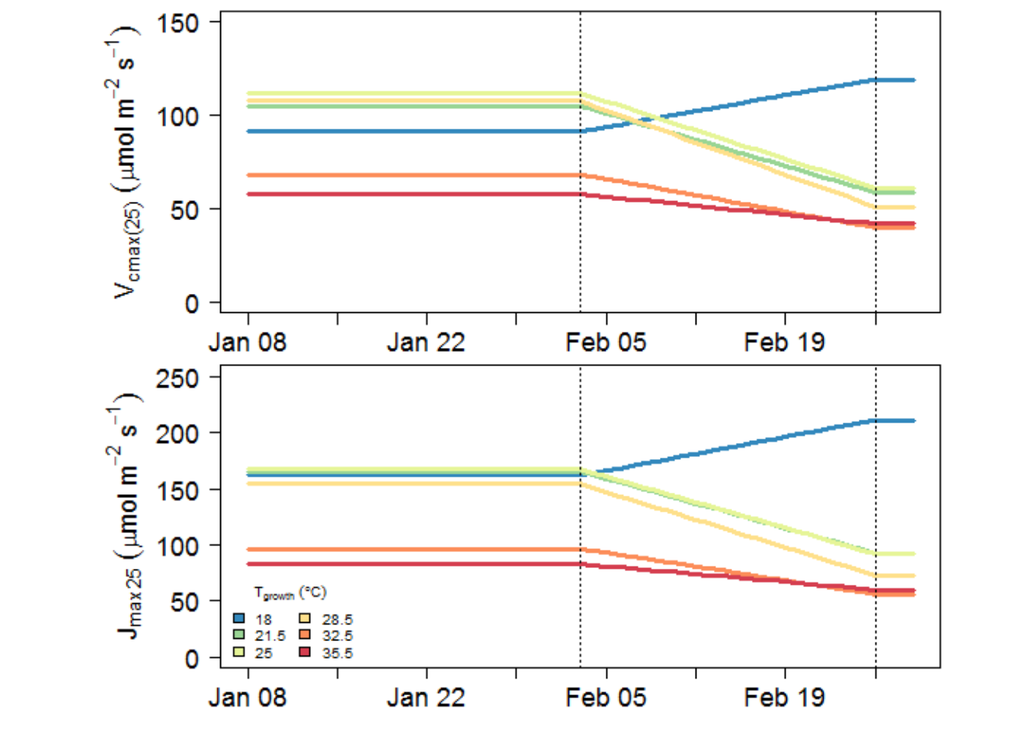

Fig.4 Vcmax and Jmax at 25<sup>o</sup>C over the experiment period.

### 3. Temperature response parameters of Vcmax and Jmax (avtivation energy ($E_{a}$) and entropy terms ($\Delta S$))

We fitted peaked Arrhenius function for apperent Vcmax and Jmax values derived from fitting ACi curves. As ACi data not available for room 2,3 and 5 we assumed similar parameters for closeby rooms as Room 1 (18<sup>o</sup>C) for Room 2 (21.5<sup>o</sup>C), Room 4 (28.5<sup>o</sup>C) for rooms 3 (25<sup>o</sup>C), Room 6 (35.5<sup>o</sup>C) for room 5 (32.5<sup>o</sup>C).

### Table 3. Parameters used to predict $A_{Day}$ (Eqn 5) using the coupled photosynthesis stomatal conductance model

| Tgrowth | g1 | g1.se | EaVcmax | EaVcmax.se | delsVcmax | delsVcmax.se | EaJmax | EaJmax.se | delsJ | delsJmax.se | JVr..at.25C. | alpha | alpha.se | theta | theta.se |
| --- | --- | --- | --- | --- | --- | --- | --- | --- | --- | --- | --- | --- | --- | --- | --- |
| 18.0 | 5.5 | 0.9 | 58.9 | 8.5 | 0.629 | 0.004 | 42.7 | 8.4 | 0.631 | 0.004 | 1.77 | 0.31 | 0.07 | 0.30 | 0.50 |
| 21.5 | 10.7 | 0.9 | 58.9 | 8.5 | 0.629 | 0.004 | 42.7 | 8.4 | 0.631 | 0.004 | 1.58 | 0.34 | 0.04 | 0.59 | 0.17 |
| 25.0 | 10.8 | 0.7 | 57.7 | 5.3 | 0.629 | 0.003 | 32.7 | 3.4 | 0.625 | 0.003 | 1.50 | 0.35 | 0.07 | 0.27 | 0.52 |
| 28.5 | 10.0 | 1.7 | 57.7 | 5.3 | 0.629 | 0.003 | 32.7 | 3.4 | 0.625 | 0.003 | 1.43 | 0.40 | 0.06 | 0.37 | 0.32 |
| 32.0 | 18.2 | 1.0 | 82.5 | 13.5 | 0.633 | 0.004 | 51.0 | 8.8 | 0.631 | 0.004 | 1.41 | 0.31 | 0.04 | 0.54 | 0.22 |
| 35.5 | 29.0 | 4.6 | 82.5 | 13.5 | 0.633 | 0.004 | 51.0 | 8.8 | 0.631 | 0.004 | 1.43 | 0.30 | 0.04 | 0.61 | 0.21 |

Ok. now we have all the parameters required by the photosynthesis model. We first used the model to predict leaf net photosynthesis measured at 4 light levels to confirm tht model performs well in all light levels (low vs high).

Input met data: Measured LICOR variables (CO2S, VpdL, PARi)

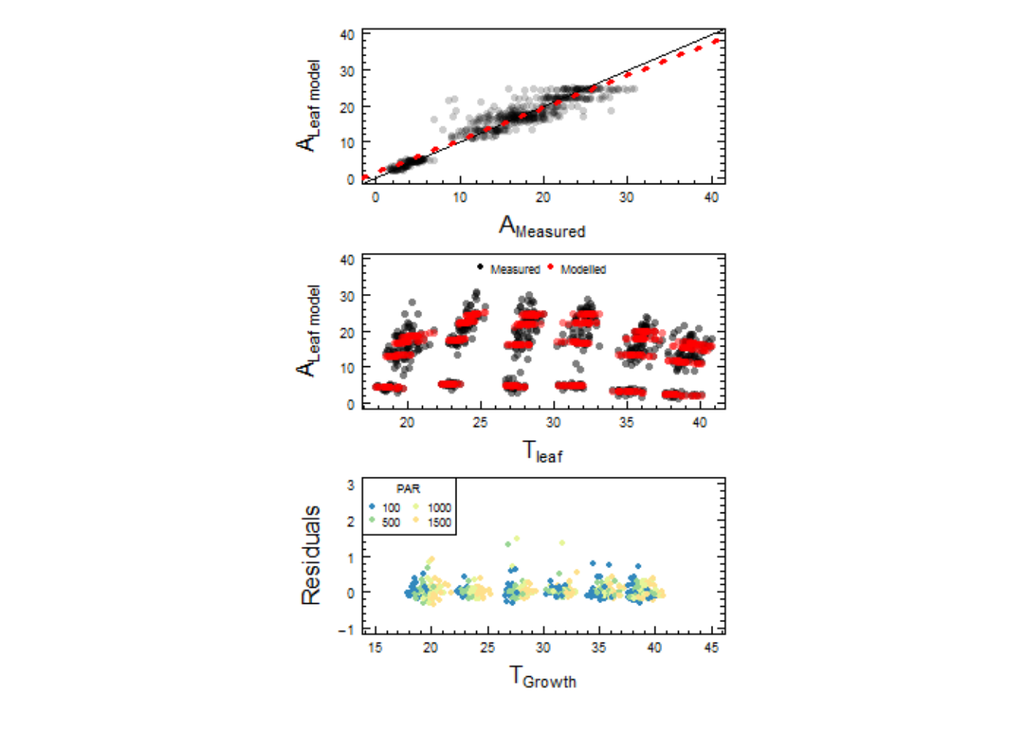

Figure 5. Measured and modelled photosynthesis. The red line is the regression fit (slope=0.9; R2=0.90)

Modelled photosynthesis showed a close fit to the measured and no systematic pattern in residuals (calculated as ($A_{predicted}$-$A_{measured}$/$A_{measured}$)) at any light level.

# ———————————————————————————————————————————————————–

## Estimation of daily carbon gain for six growth temperature treatments

### Daily GPP

We estimated GPP (gm^2) for every 15 min interval using 15 min met data (air temperature, PAR and VPD) and treatment-specific photosynthetic parameters for each growth temperature treatments and then summed for 24h. We assumed Rday=0 in GPP estimation but it was considered in daily leaf dark respiration estimation (described bellow). Met data not available for two days, 2016/01/20 and 21 (ratation dates). We assumed GPP of 2016-01-18 for this two days as the PAR similar in these three days.

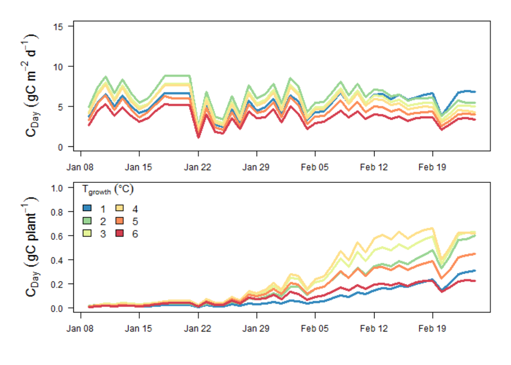

Figure 6. Modelled daily GPP for each growth temperature over experimental period

### Diurnal variation of modelled GPP

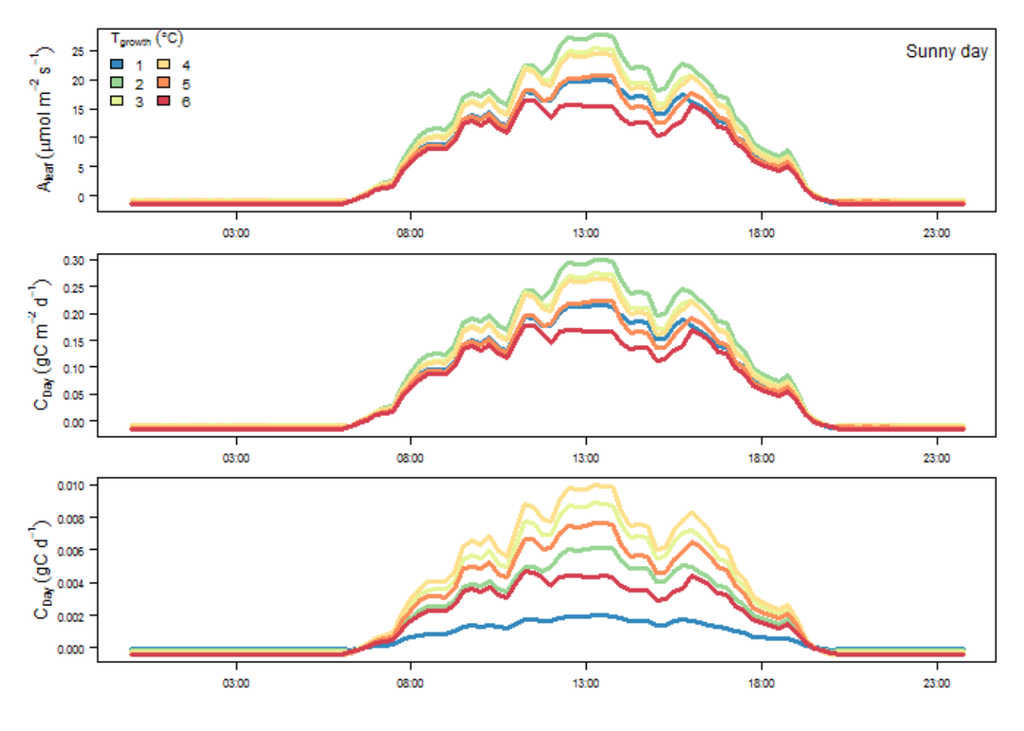

Figure 7. Diurnal variation of modelled GPP for each growth temperature in a sunny day

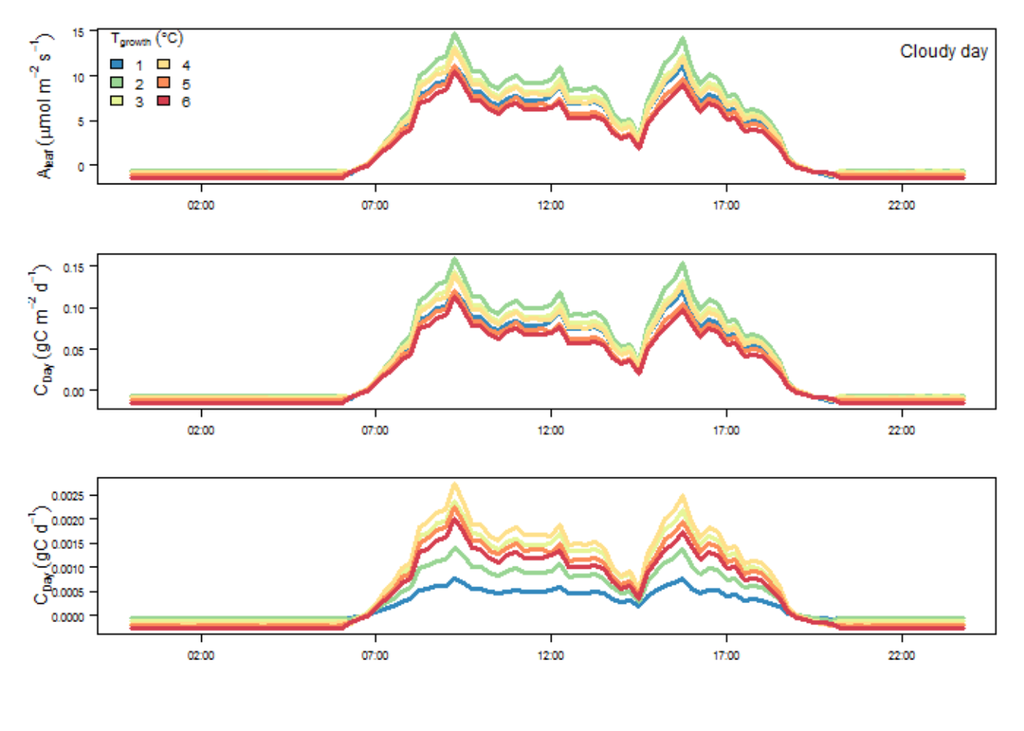

Figure 8. Diurnal variation of modelled GPP for each growth temperature in a cloudy day

### Daily leaf ($R_{m(l)}$), stem ($R_{m(s)}$) and root ($R_{m(r)}$) maintenance respiration

We used leaf, stem and root dark respiration rates (at 25<sup>o</sup>C) measured at final harvest to calculate daily respiration rate for each growth temperature treatment. We assumed common Q10 for the three organs which derived by fitting short-term temperature response for leaf respiration (Drake et al., 2017).

For day time leaf respiration, we used estimated day respiration rates from ACi curve fitting. Data available only for Room 1, 4 and 6. For orher rooms, a smooth curve was used to estimate values. Q10=0.7 (mean across rooms)

**Leaf respiration calculated for day and night seperately.**

**Stem and root respiration rates were assumed similar during day and night**

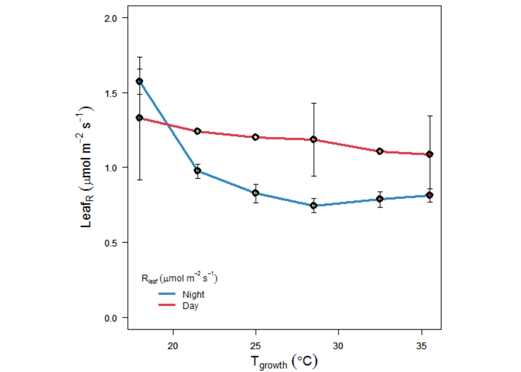

Figure 9.a Estimated daily leaf maintenance respiration rates during day and night (at 25<sup>0</sup>C)

Similar to GPP, leaf, stem and root respiration rates (gC gC^-1) were estimated at 15 min interval using air temperature data of each temperature treatment, then multiplied by tissue specific mass to estimate the total respiration (gC) and summed for 24h. We assumed $R_{light}$:$R_{dark}$ as 0.7 when estimating $R_{m(l)}$.

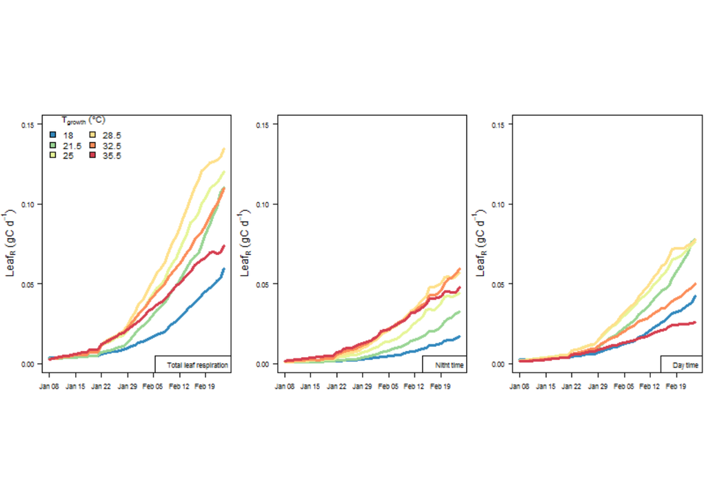

Figure 9.b Estimated daily leaf maintenance respiration over the experiment period

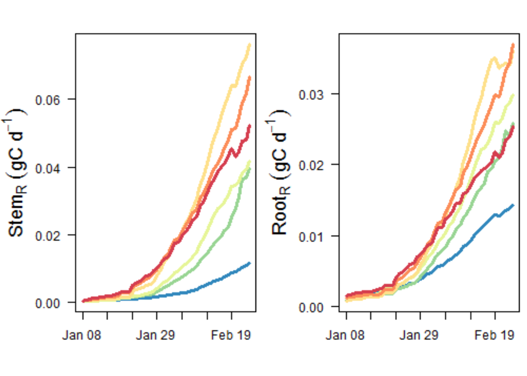

Figure 9.c Estimated daily stem and root maintenance respiration over the experiment period

## Carbon balance

Just to check whether plants have enough carbon to support growth and respiration. Assuming $GPP$=$R_{m(l)}$+$R_{m(s)}$+$R_{m(r)}$+ 1.3$\Delta$Biomass where, $\Delta$Biomass is $Mass_{final}$-$Mass_{initial}$

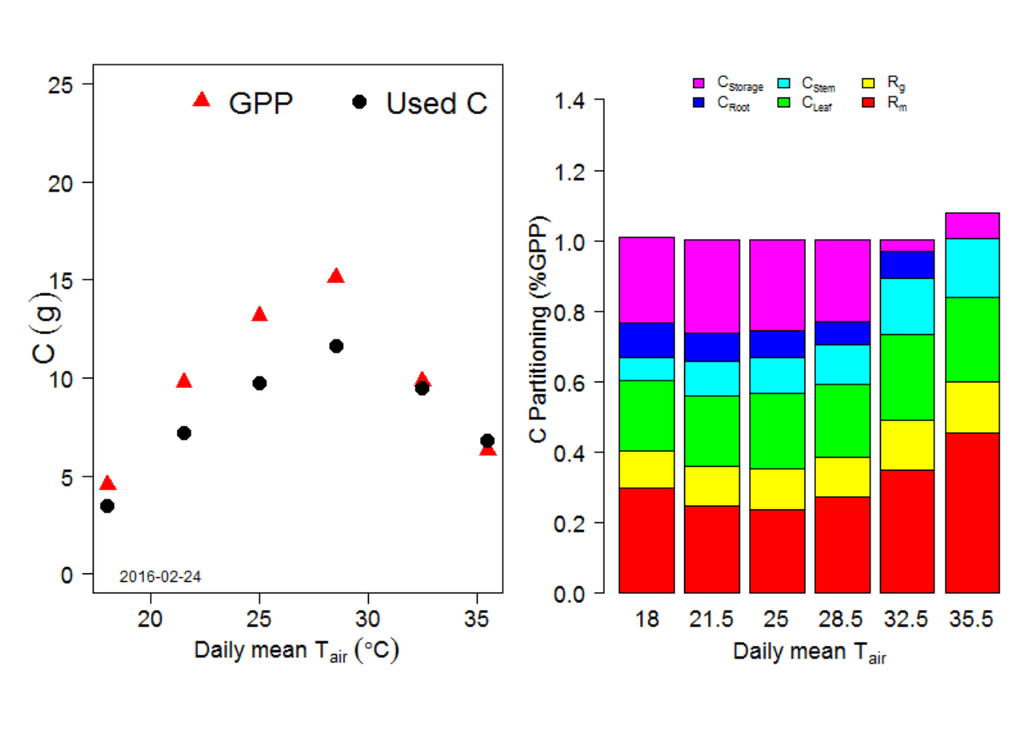

Figure 10. Estimated total GPP and total carbon use of seedlings of GREAT experiment

Possible reasons

1. Carbon balance approach we used assumed growth respiration = 30% of the biomass. This may not a fix parameter
2. Uncertainities in leaf, stem and root mass estimation. (affect maintenance respiration estimates): A sharp increase in total respiration, specially at hotter rooms can be seen in Figure 9.

# ———————————————————————————————————————————————————–

# Apply Data Assimilation (DA) with the estimates of GREAT carbon pools and fluxes

We plan to estimate five parameters (*k*, *Y*, *a<sub>f</sub>*, *a<sub>w</sub>*, *a<sub>r</sub>*) of the CBM for this experiment using GPP and maintenance respiration rates estimated as described above

### 1. Test the model for six treatments

#### parameter settings: Linear

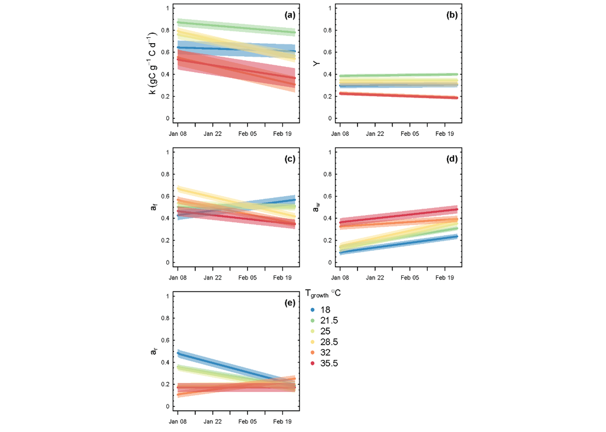

Figure 11. Modelled parameters

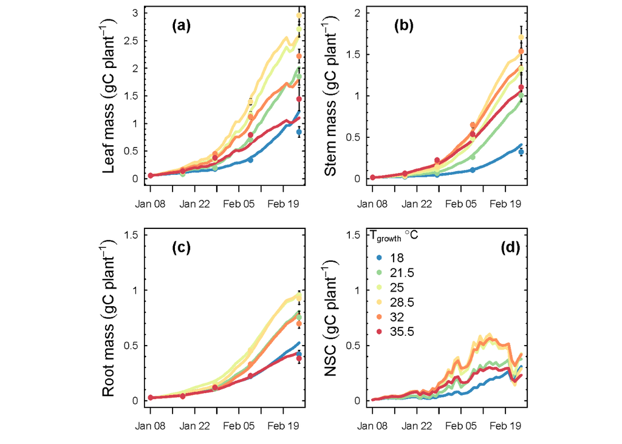

Figure 12. Modelled Biomass

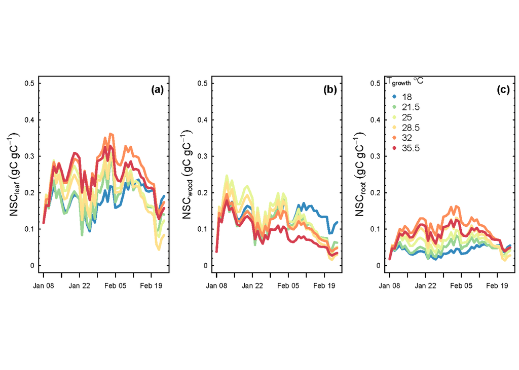

Figure 12. NSC in different tissues

#### Model comparison (linear vs quadratic): BIC values

| Temperature_treatment | BIC..linear.model. | BIC..quadratic.model. |
| --- | --- | --- |
| 18 °C | 30 | 39 |
| 28.5 °C | 149 | 176 |
| 35.5 °C | 102 | 98 |